# Prudential Live Insurance Assessment

Ruben Maso

15 Diciembre 2015

#### The idea of this script is to explore the features in terms of predictibility of the independent variable “Response”, using a independent regression for each feature.

Load libraries:

Loading the data:

```r
train <- read.table("./data/train.csv", sep=",", header=TRUE)
test <- read.table("./data/test.csv", sep=",", header=TRUE)
```

Here we remove some rows, because we can see that for example, there are no Product_Info_7==2 in the test set, so we can define this feature as binary removing those values.

```r
#Those considered as no binary:
train=dplyr::filter(train, Product_Info_7!=2)
train=dplyr::filter(train, Insurance_History_3!=2)
train=dplyr::filter(train, Medical_History_5!=3)
train=dplyr::filter(train, Medical_History_6!=2)
train=dplyr::filter(train, Medical_History_9!=3)
train=dplyr::filter(train, Medical_History_12!=1)
train=dplyr::filter(train, Medical_History_16!=2)
train=dplyr::filter(train, Medical_History_17!=1)
train=dplyr::filter(train, Medical_History_23!=2)
train=dplyr::filter(train, Medical_History_31!=2)
train=dplyr::filter(train, Medical_History_37!=3)
train=dplyr::filter(train, Medical_History_41!=2)
```

Separate categorical, binary, and other numeric variables:

```r
feat.cat <- c("Product_Info_2", "Employment_Info_2", "InsuredInfo_1", "InsuredInfo_3", "Insurance_History_4",
              "Insurance_History_7", "Insurance_History_8", "Insurance_History_9", "Family_Hist_1",
              "Medical_History_3", "Medical_History_7", "Medical_History_8", "Medical_History_11", "Medical_History_13",
              "Medical_History_14", "Medical_History_18", "Medical_History_19", "Medical_History_20", "Medical_History_21",
              "Medical_History_25",
              "Medical_History_26", "Medical_History_27", "Medical_History_28", "Medical_History_29", "Medical_History_30",
              "Medical_History_33", "Medical_History_34", "Medical_History_35", "Medical_History_36", "Medical_History_38",
              "Medical_History_39", "Medical_History_40")


feat.bin <- c("Product_Info_7", "Product_Info_6", "Product_Info_5", "Product_Info_1", "InsuredInfo_2",
              "InsuredInfo_4", "InsuredInfo_5", "InsuredInfo_6", "InsuredInfo_7", "Employment_Info_3",
              "Employment_Info_5", "Insurance_History_1", "Insurance_History_2", "Insurance_History_3",
              "Medical_History_4", "Medical_History_5", "Medical_History_6", "Medical_History_9",
              "Medical_History_12", "Medical_History_16",
              "Medical_History_17", "Medical_History_22", "Medical_History_23", "Medical_History_31",
              "Medical_History_37",
              "Medical_History_41",
              paste("Medical_Keyword_", 1:48, sep=""))

feat.numeric <- setdiff(names(test), c(feat.cat, feat.bin))
```

We will convert to 1 and zero the binary features:

```r
for (f in feat.bin) {
    levels <- unique(c(train[[f]], test[[f]]))
    train[[f]] <- as.integer(factor(train[[f]], levels=levels))-1
    test[[f]]  <- as.integer(factor(test[[f]],  levels=levels))-1
}
```

Now, lets explore predictability for each feature:

```r
response=train$Response
scores.grid <- expand.grid(columns = 1:ncol(test), score = NA)

for (i in 1:ncol(test)) {
    feat=names(test)[i]
    temp=data.frame(train[, feat])
    names(temp)=feat
    #eGrid = expand.grid(cp=0.002)
    nf  <- trainControl(method="cv", number=5, classProbs = FALSE, summaryFunction = defaultSummary)
    a= train(x=temp, y=response, method = "lm", metric="RMSE",  trControl=nf)
    #p=predict(a, train)
    scores.grid[i, 2]=mean(a$results[,"RMSE"])
    cat(mean(a$results[,"RMSE"]), "")

}
```

```
## 2.456853 2.456561 2.366602 2.451303 2.406031 2.456847 2.455704 2.456819 2.402272 2.446054 2.300177 2.270851 2.454051 2.449301 2.440267 2.461494 2.453207 2.449847 2.448247 2.448837 2.456741 2.456186 2.445485 2.435886 2.445972 2.456909 2.438434 2.456781 2.456843 2.4298 2.456782 2.456784 2.456789 2.…
```

Now that we have calculated the rmse score for each feature, we plot it:

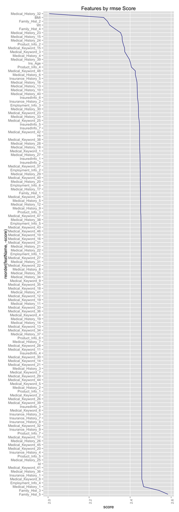

```r
scores.grid$featName=names(test)
ggplot(data=scores.grid, aes(x=reorder(featName, -score), y=score)) +
    geom_line(colour="darkblue", fill="blue", aes(group="name")) +
    theme(axis.text.x = element_text(angle = 90, hjust = 1)) +
    coord_flip() +
    ggtitle("Features by rmse Score")
```

These are the best features according a regression:

```r
head(scores.grid[order(scores.grid$score),], 10)
```

```
##    columns    score           featName
## 70      70 2.005606 Medical_History_32
## 12      12 2.270851                BMI
## 35      35 2.289409      Family_Hist_2
## 11      11 2.300177                 Wt
## 37      37 2.326345      Family_Hist_4
## 61      61 2.353732 Medical_History_23
## 53      53 2.360770 Medical_History_15
## 62      62 2.361782 Medical_History_24
## 3        3 2.366602     Product_Info_2
## 94      94 2.372836 Medical_Keyword_15
```

```r
summary(train$Medical_History_32)
```

```
##    Min. 1st Qu.  Median    Mean 3rd Qu.    Max.    NA's
##    0.00    0.00    0.00   11.97    2.00  240.00   58257
```

We can see that there are many NA’s in the most useful feature. Now, lets see the less predictive features according the regression:

```r
tail(scores.grid[order(scores.grid$score),], 10)
```

```
##     columns    score            featName
## 63       63 2.456848  Medical_History_25
## 1         1 2.456853                  Id
## 120     120 2.456864  Medical_Keyword_41
## 74       74 2.456898  Medical_History_36
## 26       26 2.456909 Insurance_History_1
## 87       87 2.456953   Medical_Keyword_8
## 16       16 2.461494   Employment_Info_4
## 39       39 2.465643   Medical_History_1
## 36       36 2.541516       Family_Hist_3
## 38       38 2.584408       Family_Hist_5
```

Lets see our independent variable and how it goes with the top 8 features. We will split the discrete or continuos variables using their mean to obtain a binary version of them.

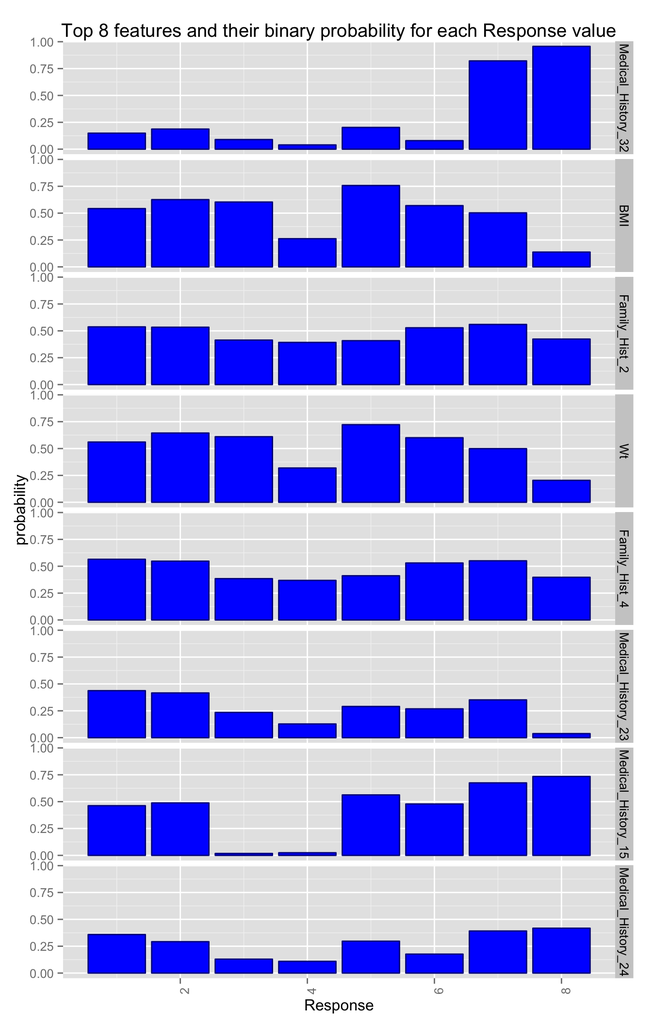

```r
data=(train[,c(head(scores.grid[order(scores.grid$score),"featName"], 8), "Response")])

# Creating binary columns using the mean
data$Medical_History_32=ifelse(data$Medical_History_32 >mean(data$Medical_History_32, na.rm=T), 1, 0)
data$BMI=ifelse(data$BMI >mean(data$BMI, na.rm=T), 1, 0)
data$Wt =ifelse(data$Wt  >mean(data$Wt , na.rm=T), 1, 0)
data$Family_Hist_4=ifelse(data$Family_Hist_4 >mean(data$Family_Hist_4, na.rm=T), 1, 0)
data$Family_Hist_2=ifelse(data$Family_Hist_2 >mean(data$Family_Hist_2, na.rm=T), 1, 0)
data$Medical_History_15=ifelse(data$Medical_History_15 >mean(data$Medical_History_15, na.rm=T), 1, 0)
data$Medical_History_24=ifelse(data$Medical_History_24 >mean(data$Medical_History_24, na.rm=T), 1, 0)

data <- melt(data, id.vars="Response")
colnames(data)[2:3]=c("Feature", "Value")

data= data %>% dplyr::group_by(Response, Feature) %>%
    dplyr::summarise(probability=mean(Value, na.rm=T))


ggplot(data=data, aes(x=Response, y=probability)) +
    geom_bar(colour="darkblue", fill="blue", stat="identity") +
    facet_grid(Feature~., as.table = TRUE)+
    theme(axis.text.x = element_text(angle = 90, hjust = 1)) +
    #coord_flip() +
    ggtitle("Top 8 features and their binary probability for each Response value")
```

And the baseline was:

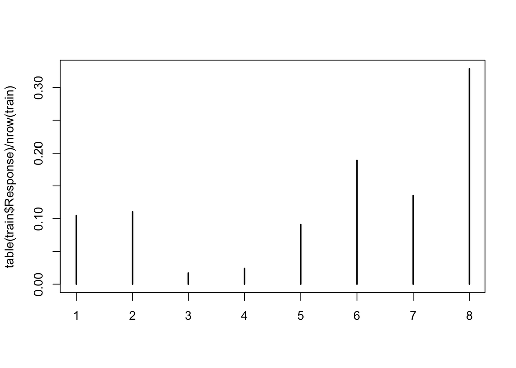

```r
plot(table(train$Response)/nrow(train))
```

Lets see quickly if the NA’s in Medical_History_32 are predictive

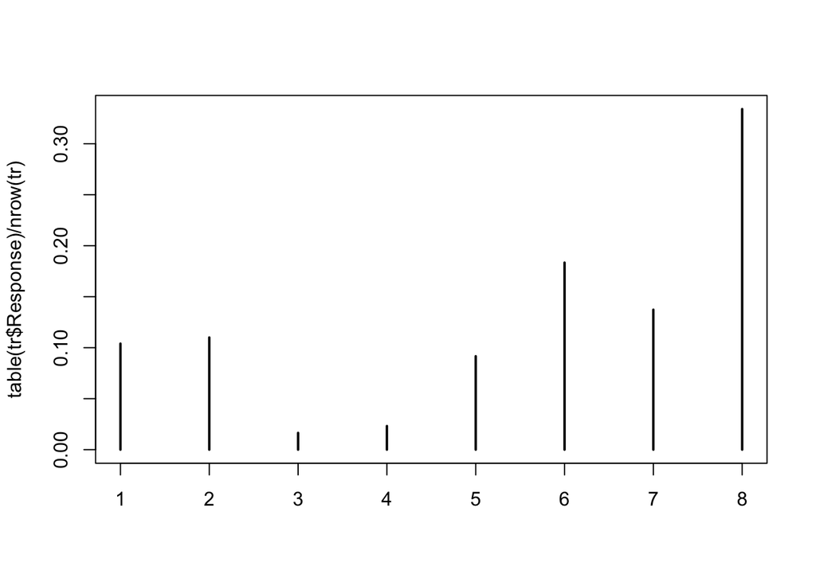

```r
tr=dplyr::filter(train, is.na(Medical_History_32))
plot(table(tr$Response)/nrow(tr))
```

We can see that those NA behave very similarly to the baseline probability that we can estimate from the train set. We have a lot of those NA values in this features.

So.. lets see the ones that are not NA: Lets see quickly if the NA’s in Medical_History_32 are predictive

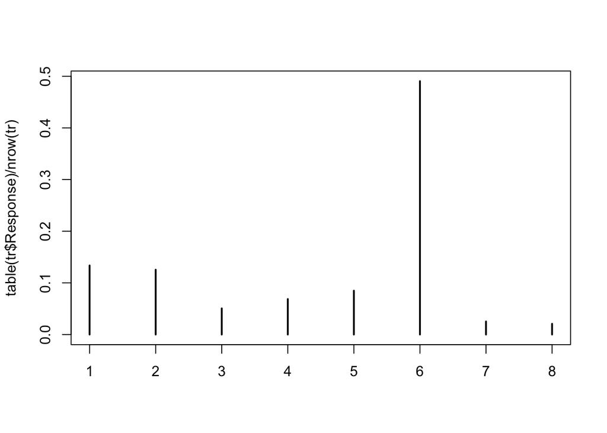

```r
tr=dplyr::filter(train, !is.na(Medical_History_32))
plot(table(tr$Response)/nrow(tr))
```